# ポアソン分布と到着間隔（指数分布）の基礎と実践

- Show All Code
- Hide All Code
- View Source

概念の直感理解・理論計算・シミュレーションから可視化まで

Author

Antigravity Pair Programming

Published

August 18, 2026

## 1 はじめに：ポアソン分布とは？

**ポアソン分布（Poisson Distribution）**は、**「ある一定の時間や空間の中で、平均して $\lambda$（ラムダ）回起こるランダムな事象が、ちょうど $k$ 回起こる確率」**を表す離散型確率分布です。

### 1.1 確率質量関数（PMF）

$$P(X = k) = \frac{\lambda^k e^{-\lambda}}{k!} \quad (k = 0, 1, 2, \dots)$$

- $\lambda > 0$ : 単位時間（または単位空間）あたりの平均発生回数
- $k \ge 0$ : 実際に観測される発生回数
- $e$ : 自然対数の底（ネイピア数 $\approx 2.71828$）

### 1.2 最も重要な統計的性質

ポアソン分布の最大の特徴は、**「期待値（平均）と分散が完全に一致する」**という点です。

$$\text{E}[X] = \lambda$$
$$\text{Var}(X) = \lambda$$

## 2 ポアソン分布が成立するための前提条件

ポアソン分布が適用できるのは、**「事象同士に互いに因果関係（連鎖や反発）がなく、完全に独立してランダムに生じる現象」**に限られます。この確率モデルを**ポアソン過程**と呼び、以下の3条件を満たす必要があります。

1. **独立性（無記憶性）**
   - ある時間帯に事象が発生したかどうかが、他の時間帯で発生する確率に全く影響を与えない。
2. **定常性（斉時性）**
   - 単位時間あたりに事象が起きる平均ペース $\lambda$ は、どの時間帯でも一定である。
3. **希少性（非集積性）**
   - ごくわずかな微小時間 $\Delta t$ の間に、事象が同時に2回以上重なって起きる確率は無視できるほど小さい。

**Note具体例：平日のコンビニでトイレを借りる客**

- **なぜ当てはまるか？**: トイレの利用は個人の生理現象や行動に依存しており、「前の客が使ったから次の客も行きたくなる」といった客同士の連鎖（因果）はありません。
- **母数と確率**: 来店客や通行人という膨大な母数（$n$）の中で、偶発的にトイレを借りる確率（$p$）はごくわずかであり、二項分布の極限（$n \to \infty, p \to 0, np = \lambda$）としてのポアソン分布に綺麗に従います。

## 3 Python による理論計算と乱数シミュレーション

まずは Python (`scipy.stats` と `numpy`) を用いて、1時間に平均 3 人 ($\lambda = 3.0$) が訪れるケースの確率計算と乱数シミュレーションを実行します。

```python
import numpy as np
from scipy.stats import poisson

lam = 3.0
k_vals = np.arange(0, 11)

# 1. 理論確率の計算 (PMF)
probs = poisson.pmf(k_vals, lam)

print(f"=== 平均発生件数 λ = {lam} の場合の確率 ===")
```

```
=== 平均発生件数 λ = 3.0 の場合の確率 ===
```

```python
for k, p in zip(k_vals, probs):
    bar = "■" * int(p * 40)
    print(f"{k:2d} 回 : {p:8.4f} ({p*100:5.1f}%) | {bar}")
```

```
 0 回 :   0.0498 (  5.0%) | ■
 1 回 :   0.1494 ( 14.9%) | ■■■■■
 2 回 :   0.2240 ( 22.4%) | ■■■■■■■■
 3 回 :   0.2240 ( 22.4%) | ■■■■■■■■
 4 回 :   0.1680 ( 16.8%) | ■■■■■■
 5 回 :   0.1008 ( 10.1%) | ■■■■
 6 回 :   0.0504 (  5.0%) | ■■
 7 回 :   0.0216 (  2.2%) |
 8 回 :   0.0081 (  0.8%) |
 9 回 :   0.0027 (  0.3%) |
10 回 :   0.0008 (  0.1%) |
```

```python
# 2. 乱数シミュレーション (10,000時間分)
np.random.seed(42)
samples = np.random.poisson(lam, size=10000)

print("\n=== 10,000回シミュレーション結果 ===")
```

```
=== 10,000回シミュレーション結果 ===
```

```python
print(f"標本平均 : {np.mean(samples):.4f} (理論値 λ = {lam})")
```

```
標本平均 : 2.9946 (理論値 λ = 3.0)
```

```python
print(f"標本分散 : {np.var(samples):.4f} (理論値 λ = {lam})")
```

```
標本分散 : 2.9666 (理論値 λ = 3.0)
```

## 4 R (ggplot2) による多角的可視化

R では `dpois`（確率密度）、`ppois`（累積分布）、`rpois`（乱数）が標準で提供されています。`ggplot2` と `patchwork` を用いて、ポアソン分布の振る舞いを多角的にプロットします。

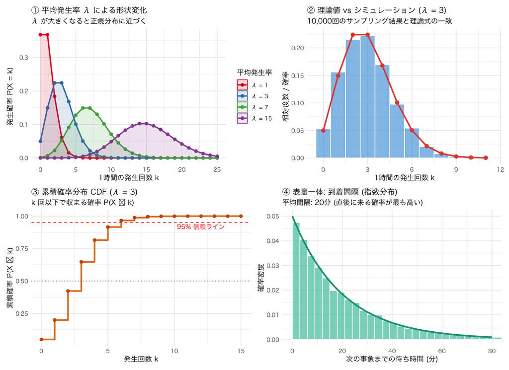

```r
library(ggplot2)
library(patchwork)
library(dplyr)

font_family <- "Hiragino Sans"
lam <- 3.0

# 1. λ の違いによる形状変化
df_lambda <- expand.grid(k = 0:25, lambda = c(1, 3, 7, 15)) %>%
  mutate(
    prob = dpois(k, lambda = lambda),
    lambda_label = factor(paste0("λ = ", lambda), levels = paste0("λ = ", c(1, 3, 7, 15)))
  )

p1 <- ggplot(df_lambda, aes(x = k, y = prob, color = lambda_label, fill = lambda_label)) +
  geom_line(linewidth = 1) +
  geom_point(size = 2) +
  geom_area(alpha = 0.15, position = "identity") +
  scale_color_brewer(palette = "Set1", name = "平均発生率") +
  scale_fill_brewer(palette = "Set1", name = "平均発生率") +
  labs(
    title = "① 平均発生率 λ による形状変化",
    subtitle = "λ が大きくなると正規分布に近づく",
    x = "1時間の発生回数 k",
    y = "発生確率 P(X = k)"
  ) +
  theme_minimal(base_family = font_family) +
  theme(plot.title = element_text(face = "bold", size = 12))

# 2. 理論値 vs シミュレーション
set.seed(42)
samples_r <- rpois(10000, lambda = lam)
df_sim <- data.frame(k = samples_r)
df_theory <- data.frame(k = 0:max(samples_r), prob = dpois(0:max(samples_r), lambda = lam))

p2 <- ggplot() +
  geom_histogram(data = df_sim, aes(x = k, y = after_stat(density)),
                 binwidth = 1, center = 0, fill = "#3498db", color = "white", alpha = 0.6) +
  geom_line(data = df_theory, aes(x = k, y = prob), color = "#e74c3c", linewidth = 1.1) +
  geom_point(data = df_theory, aes(x = k, y = prob), color = "#e74c3c", size = 2.5) +
  labs(
    title = paste0("② 理論値 vs シミュレーション (λ = ", lam, ")"),
    subtitle = "10,000回のサンプリング結果と理論式の一致",
    x = "1時間の発生回数 k",
    y = "相対度数 / 確率"
  ) +
  theme_minimal(base_family = font_family) +
  theme(plot.title = element_text(face = "bold", size = 12))

# 3. 累積確率分布 (CDF)
df_cdf <- data.frame(k = 0:15, cdf = ppois(0:15, lambda = lam))

p3 <- ggplot(df_cdf, aes(x = k, y = cdf)) +
  geom_step(color = "#e67e22", linewidth = 1.2, direction = "hv") +
  geom_point(color = "#d35400", size = 2) +
  geom_hline(yintercept = 0.5, linetype = "dotted", color = "gray40") +
  geom_hline(yintercept = 0.95, linetype = "dashed", color = "red") +
  annotate("text", x = 12, y = 0.92, label = "95% 信頼ライン", color = "red", family = font_family, size = 3.5) +
  labs(
    title = paste0("③ 累積確率分布 CDF (λ = ", lam, ")"),
    subtitle = "k 回以下で収まる確率 P(X ≤ k)",
    x = "発生回数 k",
    y = "累積確率 P(X ≤ k)"
  ) +
  theme_minimal(base_family = font_family) +
  theme(plot.title = element_text(face = "bold", size = 12))

# 4. 到着間隔 (指数分布)
rate_per_min <- lam / 60
interval_sim <- rexp(10000, rate = rate_per_min)
df_intervals <- data.frame(interval = interval_sim)
df_exp_theory <- data.frame(t = seq(0, 80, length.out = 200)) %>%
  mutate(density = dexp(t, rate = rate_per_min))

p4 <- ggplot() +
  geom_histogram(data = df_intervals, aes(x = interval, y = after_stat(density)),
                 binwidth = 3, boundary = 0, fill = "#1abc9c", color = "white", alpha = 0.6) +
  geom_line(data = df_exp_theory, aes(x = t, y = density), color = "#16a085", linewidth = 1.2) +
  coord_cartesian(xlim = c(0, 80)) +
  labs(
    title = "④ 表裏一体: 到着間隔 (指数分布)",
    subtitle = "平均間隔: 20分 (直後に来る確率が最も高い)",
    x = "次の事象までの待ち時間 (分)",
    y = "確率密度"
  ) +
  theme_minimal(base_family = font_family) +
  theme(plot.title = element_text(face = "bold", size = 12))

# 2x2 に統合
(p1 + p2) / (p3 + p4)
```

## 5 表裏一体の関係：「ポアソン分布」と「指数分布」

ポアソン過程を観測するとき、**着目する視点（回数か時間か）**によって従う確率分布が切り替わります。

| 視点 | 問い | 確率分布 | 特徴 |
| --- | --- | --- | --- |
| **回数を見る** | 一定時間内に**何回**起きるか？ | **ポアソン分布** | 離散型（0, 1, 2, … 回） |
| **時間を見る** | 事象が起きてから**何分後**に次が起きるか？ | **指数分布** | 連続型（0分以上） |

1時間に平均 $\lambda = 3$ 回起きる場合、平均待ち時間は $\frac{1}{\lambda} = \frac{1}{3}\text{時間} = 20\text{分}$ となり、待ち時間は $\text{Exp}(\text{rate} = 3/\text{hour})$ に従います。

## 6 発展：実務データへの応用

現実のデータでは、厳密なポアソン過程の前提が崩れるケースがあります。その場合は以下の手法へと拡張します。

1. **時間帯による平均発生率の変化 $\lambda(t)$**
   - 例: 昼食後の 14:00〜15:00 に利用客が集中する
   - ➔ **非斉次ポアソン過程（Inhomogeneous Poisson Process）**
2. **外部要因（気温・曜日・イベント）による影響**
   - ➔ **ポアソン回帰分析（GLM: 一般化線形モデル）**: $\log(\lambda) = \beta_0 + \beta_1 X_1 + \dots$
3. **事象が連鎖して発生する（過分散: 分散 > 平均）**
   - 感染症や口コミの拡散など
   - ➔ **負の二項分布（Negative Binomial Distribution）**